# Entregable 5

Diego Asencios Ore

2022-07-11

1. Introducción:

2. Objetivos: En el siguiente trabajo presentamos que variables afectan el índice de desarrollo humano. La siguiente data ha sido obtenida en el curso de estadística 1 del año 2020. La hipótesis que proponemos es que el índice de desarrollo humano es afectado directamente por las variables esperanza de vida, el nivel educativo y el gasto público.
3. Explicación de la dependiente y sustentar con literatura las independientes propuestas.

La variable dependiente es IDH_INDEX, trata sobre una calificación de cómo está el desarrollo económico en el mundo. Se propone como dependiente, ya que es la variable que indica el nivel en el cual los países están, siendo de menor a mayor. A mayor numero, mejor idh tiene ese país.

La esperanza de vida que ahora llamaremos “Esperanza_life” es representada por “Expectativa_hombre” (esperanza de vida del hombre) y “Expectativa_mujer” (esperanza de vida de la mujer). Utilizar la esperanza de vida como un factor que afecta el desarrollo humano es importante pues tener una vida longeva y disponer de salud es el mejor indicativo del desarrollo social de un país.

El Gasto público del gobierno que ahora llamaremos “Gasto_publico” es representado por “gasto_educacion”y “gasto_salud”. Consideramos el gasto público como un factor relevante pues se vincula directamente con el bienestar social. Los recursos asignados del Gobierno pueden mejorar las condiciones de vida sociales mediante distintas políticas públicas enfocadas, por ejemplo, en la salud y en la educación.

El grado de educación de la población que ahora denominaremos “Nivel_Educativo” es representado por “tasa_finalizacion_secundaria”, “tasa_finalizacion_primaria”y “tasa_alfabetizacion”. El factor educación es importante porque permite que los individuos puedan desarrollar su máximo potencial y llevar adelante una vida productiva de acuerdo con sus necesidades e intereses. Poseer educación permite la posibilidad de trabajar para acceder a recursos que permitan poseer una vida digna.

libreria de base de datos:

```r
library(rio)
library(cluster)
library(factoextra)
library(plyr)
library(lavaan)
library(BBmisc)
library(GPArotation)
library(matrixcalc)
library(psych)
```

```r
library(ggcorrplot)
library(ggplot2)
library(stargazer)
library(polycor)
```

la base de datos esta en:

```r
library(rio)
lkCSV="https://github.com/diegoasencios2010/PC1_EST2/blob/main/Data.xlsx?raw=true"
human_development=import(lkCSV)
```

Renombramos las variables de nuestra base de datos:

```r
names(human_development) = c("Rank", "Country", "Esperanza_vida", "Expected_schooling", "Mean_schooling", "national_income", "Expectativa_hombre", "Expectativa_mujer", "promedio_edad_poblacion", "tasa_alfabetizacion", "edad_promedio_finaliza_secundaria", "tasa_finalizacion_secundaria", "tasa_finalizacion_primaria", "HDI_INDEX", "gasto_educacion","gasto_salud")
names(human_development)
```

```
##  [1] "Rank"                              "Country"
##  [3] "Esperanza_vida"                    "Expected_schooling"
##  [5] "Mean_schooling"                    "national_income"
##  [7] "Expectativa_hombre"                "Expectativa_mujer"
##  [9] "promedio_edad_poblacion"           "tasa_alfabetizacion"
## [11] "edad_promedio_finaliza_secundaria" "tasa_finalizacion_secundaria"
## [13] "tasa_finalizacion_primaria"        "HDI_INDEX"
## [15] "gasto_educacion"                   "gasto_salud"
```

Seleccionamos nuestras variabes principales:

```r
Esperanza_life=c("Expectativa_hombre","Expectativa_mujer")
Nivel_Educativo=c("tasa_finalizacion_secundaria", "tasa_finalizacion_primaria", "tasa_alfabetizacion")
Gasto_publico=c("gasto_educacion","gasto_salud")
View(human_development)
```

#Revisamos Rangos

```r
summary(human_development[,c(Esperanza_life,Gasto_publico, Nivel_Educativo)])
```

```
##  Expectativa_hombre Expectativa_mujer gasto_educacion   gasto_salud
##  Min.   :65.70      Min.   :69.30     Min.   : 2.100   Min.   : 0.380
##  1st Qu.:72.25      1st Qu.:78.10     1st Qu.: 3.600   1st Qu.: 1.600
##  Median :74.90      Median :80.30     Median : 4.400   Median : 3.000
##  Mean   :75.32      Mean   :80.46     Mean   : 4.675   Mean   : 3.871
##  3rd Qu.:79.10      3rd Qu.:83.60     3rd Qu.: 5.350   3rd Qu.: 5.460
##  Max.   :82.00      Max.   :87.70     Max.   :12.800   Max.   :13.870
##  tasa_finalizacion_secundaria tasa_finalizacion_primaria tasa_alfabetizacion
##  Min.   :47.4                 Min.   :84.70              Min.   : 80.20
##  1st Qu.:90.4                 1st Qu.:95.20              1st Qu.: 94.50
##  Median :93.7                 Median :96.40              Median : 98.10
##  Mean   :91.9                 Mean   :95.81              Mean   : 96.57
##  3rd Qu.:96.0                 3rd Qu.:98.20              3rd Qu.: 99.00
##  Max.   :99.4                 Max.   :99.70              Max.   :100.00
```

e)SITUACIÓN MUNDIAL

Veamos la situación mundial desde el comportamiento de las variables independientes, utilizando análisis de clusters, siguiendo la técnica jerárquica.El primer paso es preparar los datos para el análisis cluster.

```r
data=human_development[,c(Esperanza_life, Gasto_publico, Nivel_Educativo)]
data=data[sample(nrow(data), 103), ]
```

Creamos un objeto que concadene los 3 subsets, el cual usaremos en las técnicas de clusterización

```r
paraCluster=(data[,c(Esperanza_life, Gasto_publico, Nivel_Educativo)])
```

Se calculan las distancias entre los valores de los casos

```r
library(cluster)
g.dist = daisy(paraCluster, metric="gower")
```

Se piden 4 grupos, correspondientes a los 3 subsets, a través de la técnica agnes en un objeto llamado reg.anes. Con este último creamos una nueva columna en el objeto (plaraClustrer) elaborado.

```r
set.seed(123)
library(factoextra)

res.agnes<- hcut(g.dist, k = 4,hc_func='agnes',hc_method = "ward.D")

data$clustAG=res.agnes$cluster
```

#Exploramos resultados. Aquí vemos las características en cada cluster. Se ha calculado la media en cada variable para cada clase.

```r
library(plyr)
aggregate(cbind(Expectativa_hombre,Expectativa_mujer, tasa_finalizacion_secundaria, tasa_finalizacion_primaria, tasa_alfabetizacion, gasto_educacion, gasto_salud)~ clustAG, data=data,mean)
```

```
##   clustAG Expectativa_hombre Expectativa_mujer tasa_finalizacion_secundaria
## 1       1           74.55333          79.00667                     89.82333
## 2       2           79.68684          84.01316                     94.89211
## 3       3           70.74815          77.92963                     94.11481
## 4       4           72.88750          77.61250                     78.05000
##   tasa_finalizacion_primaria tasa_alfabetizacion gasto_educacion gasto_salud
## 1                   95.71333            93.32000        4.116667    4.229000
## 2                   97.08789            98.60263        5.392105    4.346579
## 3                   97.02593            97.72963        4.322222    3.022222
## 4                   86.06250            95.17500        4.550000    3.137500
```

• Se visualiza la forma en que se estructuran los clústeres a través de un dendograma

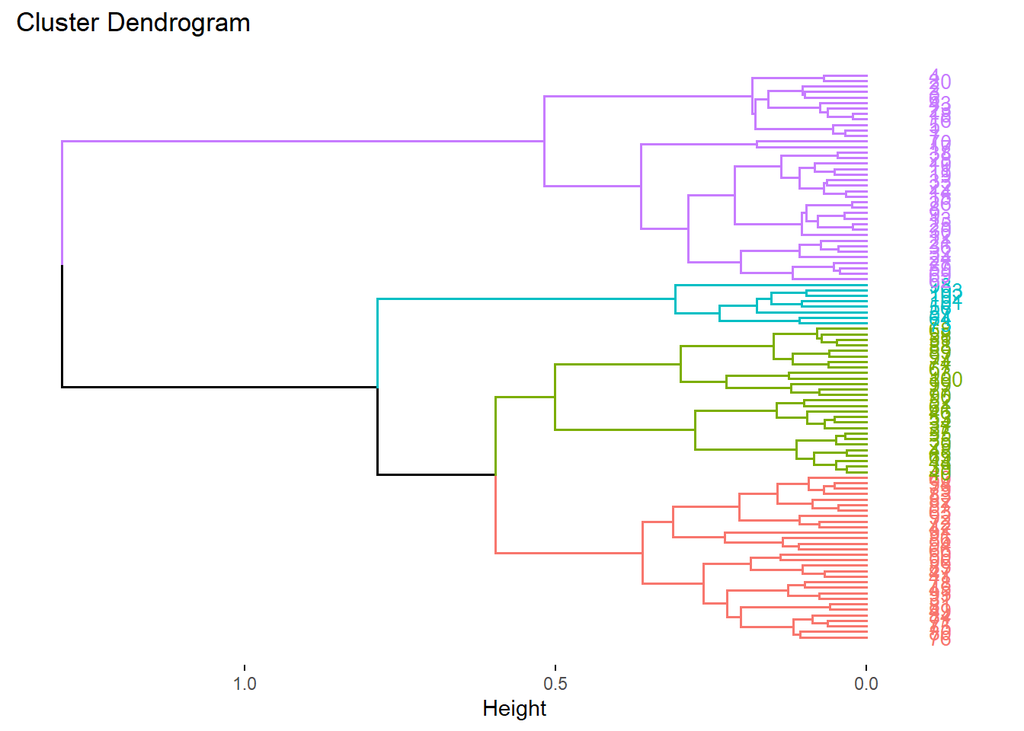

```r
fviz_dend(res.agnes, cex = 0.7, horiz = T)
```

#PREPARACIÓN DE LATENTES

Segun nuestro marco teórico tenemos tres latentes: la esperanza de vida, el nivel educativo y el gasto público.

```r
model1 <- ' Esperanza_life =~ Expectativa_hombre + Expectativa_mujer

Nivel_Educativo =~ tasa_finalizacion_secundaria + tasa_finalizacion_primaria + tasa_alfabetizacion

gasto_publico  =~ gasto_educacion + gasto_salud '
```

```r
theDataNorm=scale(data)
library(lavaan)
```

```r
cfa_fit <- cfa(model1, data=theDataNorm,
           std.lv=TRUE,
           missing="fiml")
allParamCFA=parameterEstimates(cfa_fit,standardized = T)
allFitCFA=as.list(fitMeasures(cfa_fit))
```

Veamos resultados:

Si cada indicador tiene una buena conexión con su latente (ver p valor):

```r
allParamCFA[allParamCFA$op=="=~",]
```

```
##               lhs op                          rhs   est    se      z pvalue
## 1  Esperanza_life =~           Expectativa_hombre 0.797 0.100  8.010  0.000
## 2  Esperanza_life =~            Expectativa_mujer 1.087 0.101 10.790  0.000
## 3 Nivel_Educativo =~ tasa_finalizacion_secundaria 0.807 0.097  8.274  0.000
## 4 Nivel_Educativo =~   tasa_finalizacion_primaria 0.783 0.097  8.085  0.000
## 5 Nivel_Educativo =~          tasa_alfabetizacion 0.422 0.106  3.965  0.000
## 6   gasto_publico =~              gasto_educacion 0.166 0.167  0.999  0.318
## 7   gasto_publico =~                  gasto_salud 0.529 0.439  1.205  0.228
##   ci.lower ci.upper std.lv std.all std.nox
## 1    0.602    0.992  0.797   0.801   0.801
## 2    0.890    1.285  1.087   1.093   1.093
## 3    0.615    0.998  0.807   0.810   0.810
## 4    0.593    0.973  0.783   0.787   0.787
## 5    0.213    0.630  0.422   0.424   0.424
## 6   -0.160    0.493  0.166   0.167   0.167
## 7   -0.331    1.390  0.529   0.532   0.532
```

Averigüemos qué tan bien salió el modelo:

El ChiSquare es NO significativo? (p_value debe ser mayor a 0.05 para que sea bueno)

```r
allFitCFA[c("chisq", "df", "pvalue")]
```

```
## $chisq
## [1] 25.21081
##
## $df
## [1] 11
##
## $pvalue
## [1] 0.008490322
```

El Índice Tucker Lewi es mayor a 0.9?

```r
allFitCFA$tli
```

```
## [1] 0.8926417
```

La Raíz del error cuadrático medio de aproximación es menor a 0.05?

```r
allFitCFA[c('rmsea.ci.lower','rmsea' ,'rmsea.ci.upper')]
```

```
## $rmsea.ci.lower
## [1] 0.05390733
##
## $rmsea
## [1] 0.1119939
##
## $rmsea.ci.upper
## [1] 0.1702062
```

#scores

```r
lavPredict(cfa_fit)
```

```
##        Esprn_ Nvl_Ed gst_pb
##   [1,] -0.648  0.388  0.206
##   [2,] -1.675 -0.092  0.411
##   [3,]  0.923 -0.343 -0.123
##   [4,]  0.205  0.560 -0.246
##   [5,]  0.005 -1.149 -0.908
##   [6,]  1.554  0.760 -0.044
##   [7,]  0.892  0.342 -0.138
##   [8,]  0.941  1.070  1.416
##   [9,]  2.490  1.153  0.864
##  [10,]  1.186  0.856  0.135
##  [11,] -0.406  0.089 -0.181
##  [12,] -1.165 -0.369 -0.771
##  [13,]  1.046  0.890  0.390
##  [14,]  0.449  0.473 -0.297
```

[output cut: 89 more lines]

```r
allScores=as.data.frame(lavPredict(cfa_fit))
library(BBmisc)
```

```r
library(lavaan)

human_development$esperanzalife=normalize(lavPredict(cfa_fit),
                    method = "range",
                    margin=2,
                    range = c(0, 1))
human_development$niveleducativo=normalize(lavPredict(cfa_fit),
                    method = "range",
                    margin=2,
                    range = c(0, 1))
human_development$gastopublico=normalize(lavPredict(cfa_fit),
                    method = "range",
                    margin=2,
                    range = c(0, 1))
```

d)Regresión y prueba de hipotesis

Para hacer el modelo de regresión lineal hemos usado las variables incluídas dentro de los objetos creados (las cuales son nuestras variables principales que afectan el indice de desarrollo humano): “Esperanza_life”, “Gasto_publico”, “Nivel_Educativo”. Así, Esperanza_life es representado por “Expectativa_hombre”,“Expectativa_mujer”. “Gasto_publico” es representado por “gasto_educacion”,“gasto_salud”. “Nivel_Educativo” es representado por “tasa_finalizacion_secundaria”, “tasa_finalizacion_primaria”, “tasa_alfabetizacion”.

```r
NUEVO=human_development[,c("HDI_INDEX", "Expectativa_hombre","Expectativa_mujer",
"tasa_finalizacion_secundaria", "tasa_finalizacion_primaria", "tasa_alfabetizacion", "gasto_educacion","gasto_salud")]
```

```r
hipotesis=formula(NUEVO, "HDI_INDEX" ~ "Expectativa_hombre"+"Expectativa_mujer" +
"tasa_finalizacion_secundaria"+ "tasa_finalizacion_primaria"+ "tasa_alfabetizacion"+ "gasto_educacion"+"gasto_salud")
```

```r
library(stargazer)
resultado=lm(formula = hipotesis, data= NUEVO)
summary(resultado)
```

```
##
## Call:
## lm(formula = hipotesis, data = NUEVO)
##
## Residuals:
##      Min       1Q   Median       3Q      Max
## -0.08927 -0.02226  0.00416  0.02342  0.06952
##
## Coefficients:
##                                Estimate Std. Error t value Pr(>|t|)
## (Intercept)                  -7.915e-01  1.287e-01  -6.151 1.81e-08 ***
## Expectativa_hombre            4.040e-03  1.746e-03   2.314 0.022820 *
## Expectativa_mujer             7.976e-03  2.268e-03   3.516 0.000672 ***
## tasa_finalizacion_secundaria  2.001e-03  6.507e-04   3.075 0.002750 **
## tasa_finalizacion_primaria   -2.074e-05  1.345e-03  -0.015 0.987732
## tasa_alfabetizacion           4.897e-03  1.090e-03   4.491 1.99e-05 ***
## gasto_educacion               3.506e-03  2.093e-03   1.675 0.097164 .
## gasto_salud                   2.870e-03  1.211e-03   2.371 0.019784 *
## ---
## Signif. codes:  0 '***' 0.001 '**' 0.01 '*' 0.05 '.' 0.1 ' ' 1
##
## Residual standard error: 0.03366 on 95 degrees of freedom
## Multiple R-squared:  0.7876, Adjusted R-squared:  0.772
## F-statistic: 50.33 on 7 and 95 DF,  p-value: < 2.2e-16
```

```r
tanova= anova(resultado)
stargazer(tanova,type = 'text',summary = F,title = "Table de Análisis de Varianza")
```

```
##
## Table de Análisis de Varianza
## ==============================================================
##                              Df Sum Sq Mean Sq F value Pr(> F)
## --------------------------------------------------------------
## Expectativa_hombre           1  0.272   0.272  239.785    0
## Expectativa_mujer            1  0.062   0.062  54.783     0
## tasa_finalizacion_secundaria 1  0.031   0.031  27.236  0.00000
## tasa_finalizacion_primaria   1  0.0001 0.0001   0.088   0.767
## tasa_alfabetizacion          1  0.024   0.024  21.372  0.00001
## gasto_educacion              1  0.004   0.004   3.422   0.067
## gasto_salud                  1  0.006   0.006   5.619   0.020
## Residuals                    95 0.108   0.001
## --------------------------------------------------------------
```

Para confirmar esta hipotesis, debemos realizar algunos diagnósticos adicionales.

Lineablidad:

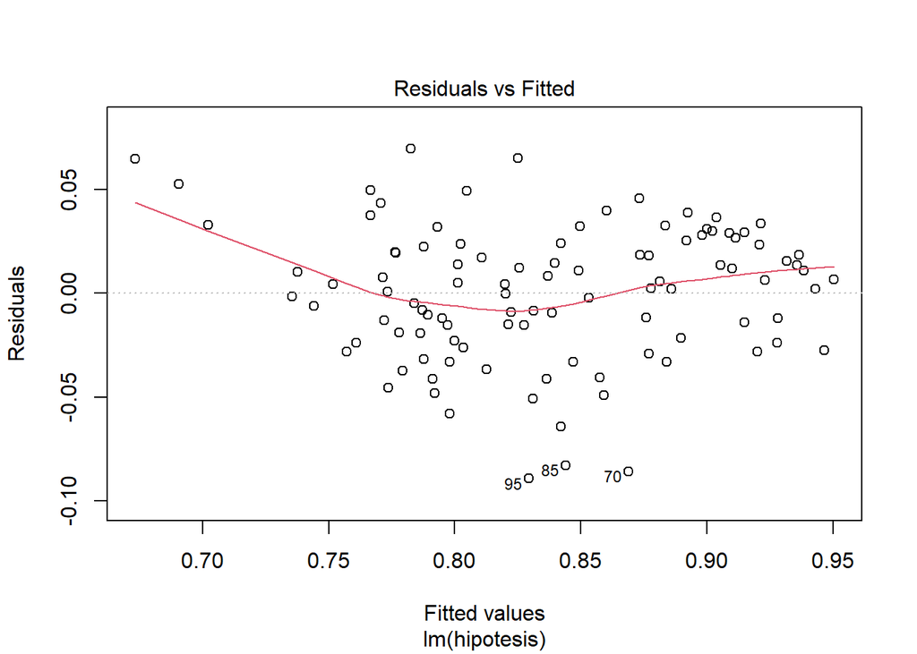

```r
plot(resultado, 1)
```

Homocedasticidad: se asume que el error del modelo de regresión no afecta la varianza o dispersión de la estimación.

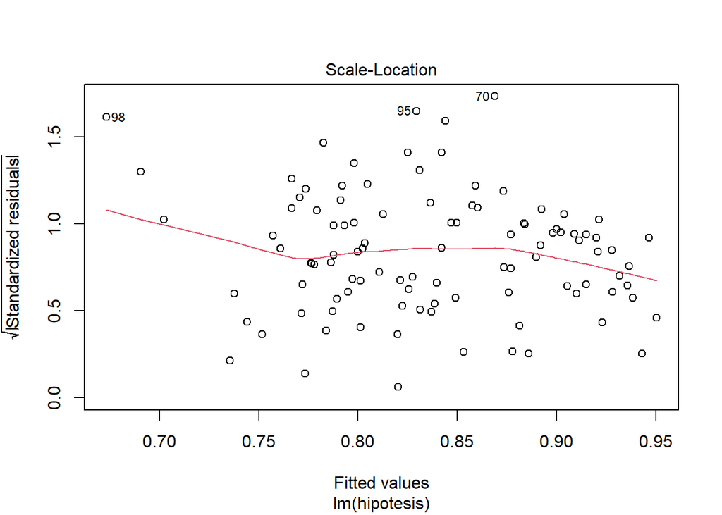

```r
plot(resultado, 3)
```

Test Breusch-Pagan:

```r
library(lmtest)
bptest(resultado)
```

```
##
##  studentized Breusch-Pagan test
##
## data:  resultado
## BP = 13.199, df = 7, p-value = 0.06741
```

El p-value de esta prueba es mayor a 0.05, por lo que no se rechaza que el modelo muestra una homocedasticidad entre las variables.

Normalidad de residuos

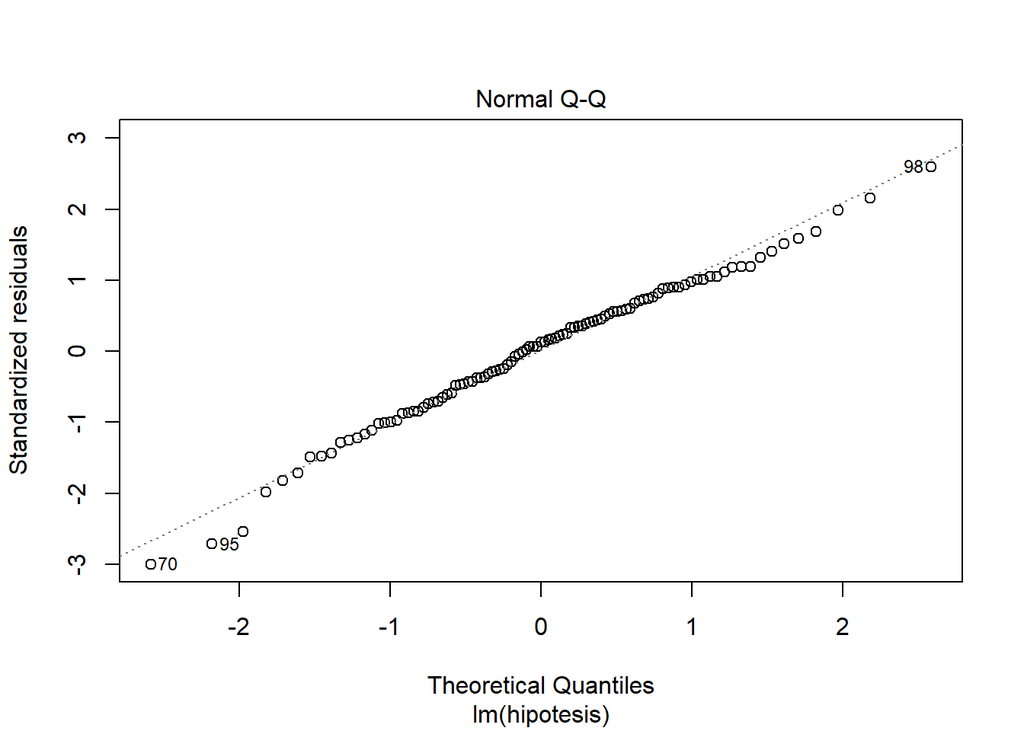

```r
plot(resultado, 2)
```

Test de Shapiro-Wilk con residuales

```r
shapiro.test(resultado$residuals)
```

```
##
##  Shapiro-Wilk normality test
##
## data:  resultado$residuals
## W = 0.98527, p-value = 0.3122
```

El p-value en la muestra de shapiro indica que es 0.3122, es decir mayor a 0.05, por lo que significa que no se rechaza que en el modelo existe una normalidad de residuos.

Test de no multicolinedad:

```r
library(DescTools)
VIF(resultado)
```

```
##           Expectativa_hombre            Expectativa_mujer
##                     4.856979                     5.653893
## tasa_finalizacion_secundaria   tasa_finalizacion_primaria
##                     1.971059                     1.922322
##          tasa_alfabetizacion              gasto_educacion
##                     1.385672                     1.076732
##                  gasto_salud
##                     1.072141
```

Observamos que solo una variable independiente es son mayor a 5, por lo que existe una correlación entre ellos, es decir, hay problema alguno entre ellos.

Valores influyentes:

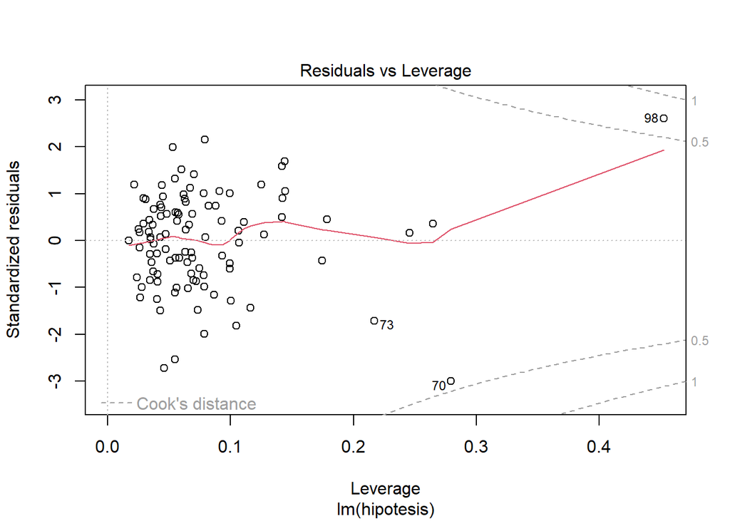

```r
plot(resultado, 5)
```

índice de Cook y valores predecidos: Existencia de casos influyentes

```r
checkHip2=as.data.frame(influence.measures(resultado)$is.inf)
head(checkHip2)
```

```
##   dfb.1_ dfb.Expcttv_h dfb.Expcttv_m dfb.ts_fnlzcn_s dfb.ts_fnlzcn_p dfb.ts_l
## 1  FALSE         FALSE         FALSE           FALSE           FALSE    FALSE
## 2  FALSE         FALSE         FALSE           FALSE           FALSE    FALSE
## 3  FALSE         FALSE         FALSE           FALSE           FALSE    FALSE
## 4  FALSE         FALSE         FALSE           FALSE           FALSE    FALSE
## 5  FALSE         FALSE         FALSE           FALSE           FALSE    FALSE
## 6  FALSE         FALSE         FALSE           FALSE           FALSE    FALSE
##   dfb.gst_d dfb.gst_s dffit cov.r cook.d   hat
## 1     FALSE     FALSE FALSE FALSE  FALSE FALSE
## 2     FALSE     FALSE FALSE FALSE  FALSE FALSE
## 3     FALSE     FALSE FALSE FALSE  FALSE FALSE
## 4     FALSE     FALSE FALSE FALSE  FALSE FALSE
## 5     FALSE     FALSE FALSE FALSE  FALSE FALSE
## 6     FALSE     FALSE FALSE FALSE  FALSE FALSE
```

```r
checkHip2[checkHip2$cook.d & checkHip2$hat,]
```

```
##  [1] dfb.1_          dfb.Expcttv_h   dfb.Expcttv_m   dfb.ts_fnlzcn_s
##  [5] dfb.ts_fnlzcn_p dfb.ts_l        dfb.gst_d       dfb.gst_s
##  [9] dffit           cov.r           cook.d          hat
## <0 rows> (or 0-length row.names)
```

#El modelo propuesto aporta 77%.

f)CONCLUSIONES

A través del desarrollo de cluster concluimos que es posible clusterizar los datos en 3 grupos. Asimismo, a través del coeficiente de silueta se observa una clusterización exitosa, aunque con valores bajos o medianos, menores a 0.4. En ese sentido, igualmente, a través de las diversas téncias, se recomienda solo 1 clúster. (Análisis Cluster y Anexo 3)

g)ANEXO 1: EXPLORACIÓN DE LATENTES

```r
DATS=(data[,c(Esperanza_life, Gasto_publico, Nivel_Educativo)])
```

```r
library(polycor)
corMatrix=polycor::hetcor(DATS)$correlations
```

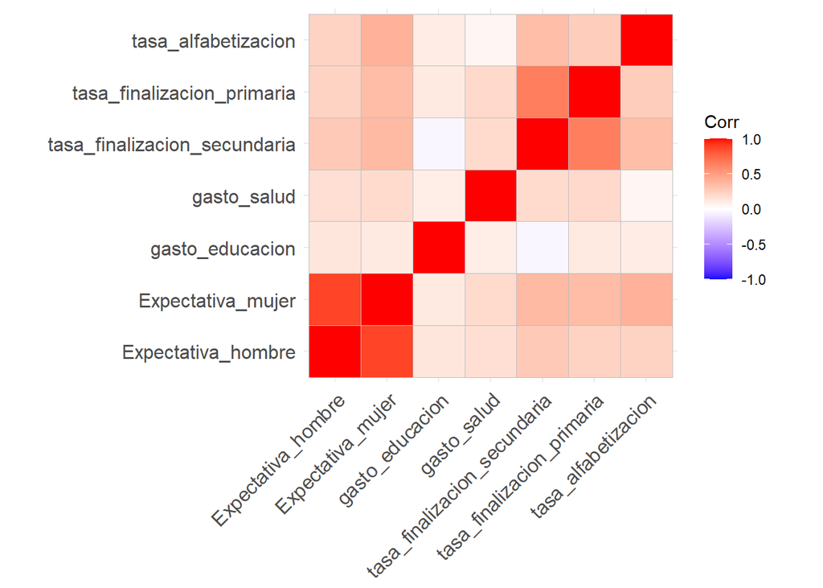

```r
library(ggcorrplot)
ggcorrplot(corMatrix)
```

```r
library(psych)
psych::KMO(corMatrix)
```

```
## Kaiser-Meyer-Olkin factor adequacy
## Call: psych::KMO(r = corMatrix)
## Overall MSA =  0.57
## MSA for each item =
##           Expectativa_hombre            Expectativa_mujer
##                         0.52                         0.56
##              gasto_educacion                  gasto_salud
##                         0.36                         0.88
## tasa_finalizacion_secundaria   tasa_finalizacion_primaria
##                         0.63                         0.60
##          tasa_alfabetizacion
##                         0.57
```

# Verificar si la matriz de correlaciones es adecuada

```r
cortest.bartlett(corMatrix,n=nrow(data))$p.value>0.05
```

```
## [1] FALSE
```

```r
library(matrixcalc)

is.singular.matrix(corMatrix)
```

```
## [1] FALSE
```

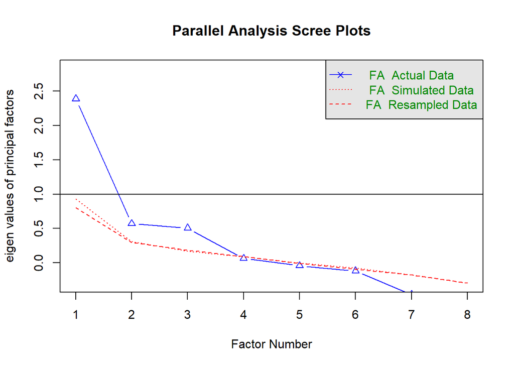

```
## Parallel analysis suggests that the number of factors =  3  and the number of components =  NA
```

```r
fa.parallel(data,fm = 'ML', fa = 'fa',correct = T)
```

```r
library(GPArotation)
resfa <- fa(DATS,
            nfactors = 3,
            cor = 'mixed',
            rotate = "varimax",
            fm="minres")
print(resfa$loadings)
```

```
##
## Loadings:
##                              MR1    MR2    MR3
## Expectativa_hombre            0.986  0.159
## Expectativa_mujer             0.841  0.276  0.193
## gasto_educacion               0.123
## gasto_salud                   0.148  0.224
## tasa_finalizacion_secundaria  0.154  0.722  0.192
## tasa_finalizacion_primaria    0.108  0.854  0.109
## tasa_alfabetizacion           0.199  0.164  0.965
##
##                  MR1   MR2   MR3
## SS loadings    1.790 1.431 1.021
## Proportion Var 0.256 0.204 0.146
## Cumulative Var 0.256 0.460 0.606
```

```r
print(resfa$loadings,cutoff = 0.15)
```

```
##
## Loadings:
##                              MR1    MR2    MR3
## Expectativa_hombre            0.986  0.159
## Expectativa_mujer             0.841  0.276  0.193
## gasto_educacion
## gasto_salud                          0.224
## tasa_finalizacion_secundaria  0.154  0.722  0.192
## tasa_finalizacion_primaria           0.854
## tasa_alfabetizacion           0.199  0.164  0.965
##
##                  MR1   MR2   MR3
## SS loadings    1.790 1.431 1.021
## Proportion Var 0.256 0.204 0.146
## Cumulative Var 0.256 0.460 0.606
```

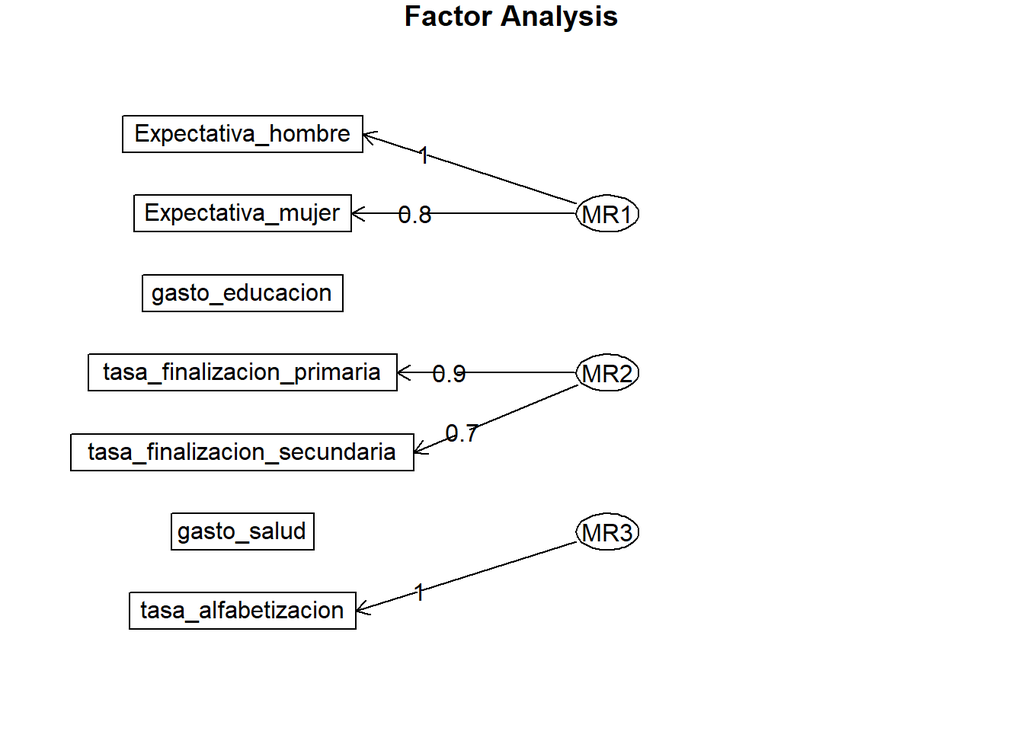

```r
fa.diagram(resfa)
```

#ANEXO 2: JUSTIFICACIÓN DE USO DE PACKAGES

1. RIO= Tiene funcionalidad de importar y exportar datos de diferentes formatos. Como excel y SPSS. Ademas, que sirve para poder leer estos.

Cluster= Sirve para poder analizar conjuntos conglomerados agrupando los datos de manera homogenea dentro de diferentes grupos con similares varianzas. Nos sirve par facilitarnos y precisar mejor las analisis sobre estos datos

Factoextra= Sirve para la visualizacion y graficacion de los resultados de las multivariables.

Plyr= Es una herramientas para dividir, aplicar y combinar datos

Lavaan= Sirve para el analisis de las variables latentes

BBmisc= Sirve para traer funciones auxiliares diversas para B.Bisch

GPArotation= Es el GPA factor de rotacion

matrixcalc= Para traer una colección de funciones para cálculos matriciales

Psych= Procedimientos para la investigación psicológica, psicométrica y de personalidad

ggcorrplot= Para la visualizacion de la correlacion en la matrix, se usa ggplot2

polycor= Para analizar las correlaciones policóricas y poliseriales

stargazer= Tablas de estadísticas resumidas y de regresión bien formateadas

ggplot2= Crea formas elegantes de poder observar la data

#ANEXO 3: EXPLORACIÓN DE CLUSTERS

```r
paraCluster=(data[,c(Esperanza_life, Gasto_publico, Nivel_Educativo)])
```

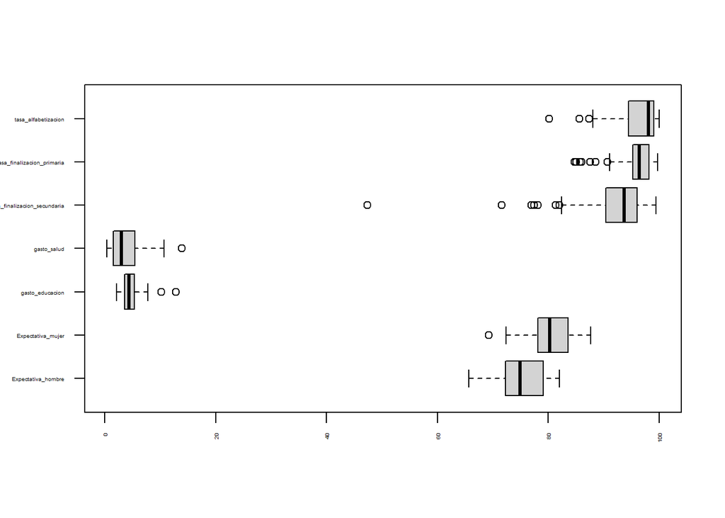

```r
boxplot(paraCluster[,c(Esperanza_life, Gasto_publico, Nivel_Educativo)],horizontal=T,las=2,cex.axis=0.3)
```

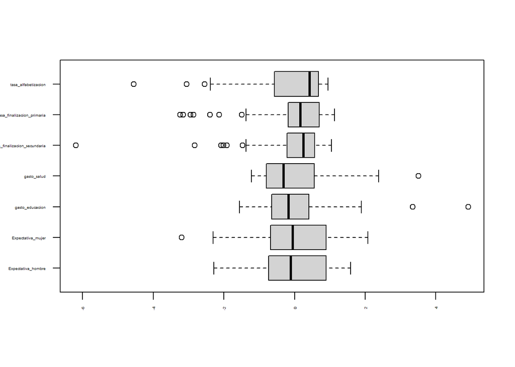

```r
boxplot(scale(paraCluster[,c(Esperanza_life, Gasto_publico, Nivel_Educativo)]),horizontal=T,las=2,cex.axis=0.3)
```

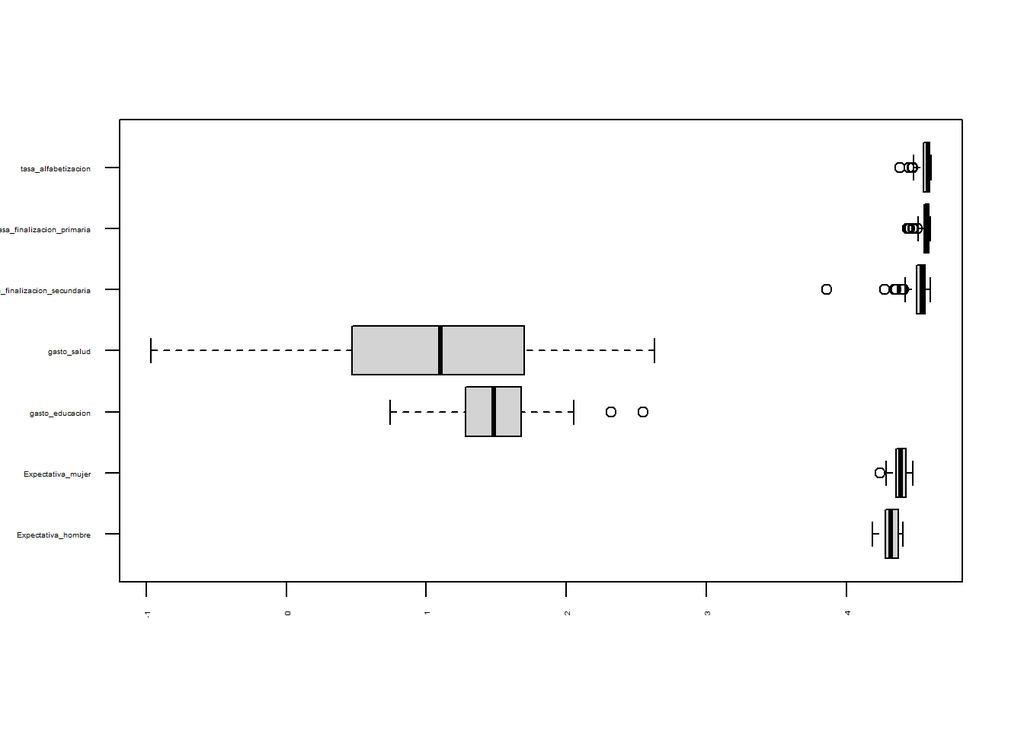

```r
boxplot(log(paraCluster[,c(Esperanza_life, Gasto_publico, Nivel_Educativo)]),horizontal=T,las=2,cex.axis=0.3)
```

```r
library(cluster)
set.seed(123)
g.dist = daisy(paraCluster[,], metric="gower")
```

PAM

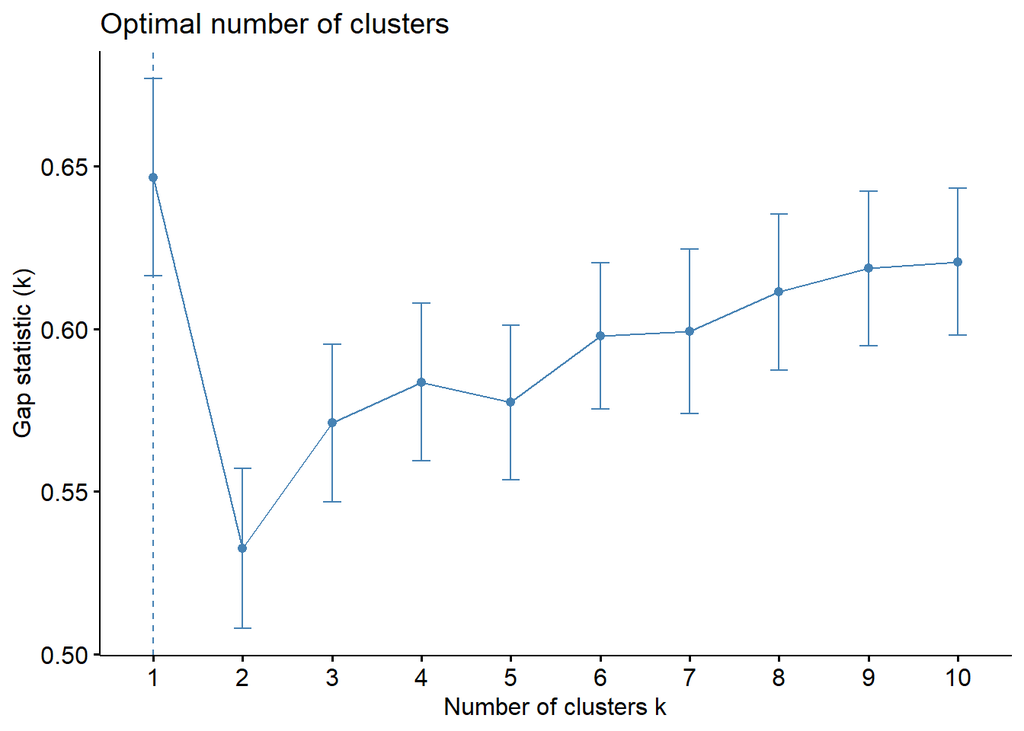

```r
set.seed(123)
library(factoextra)
fviz_nbclust(paraCluster, pam,diss=g.dist,method = "gap_stat",k.max = 10,verbose = F)
```

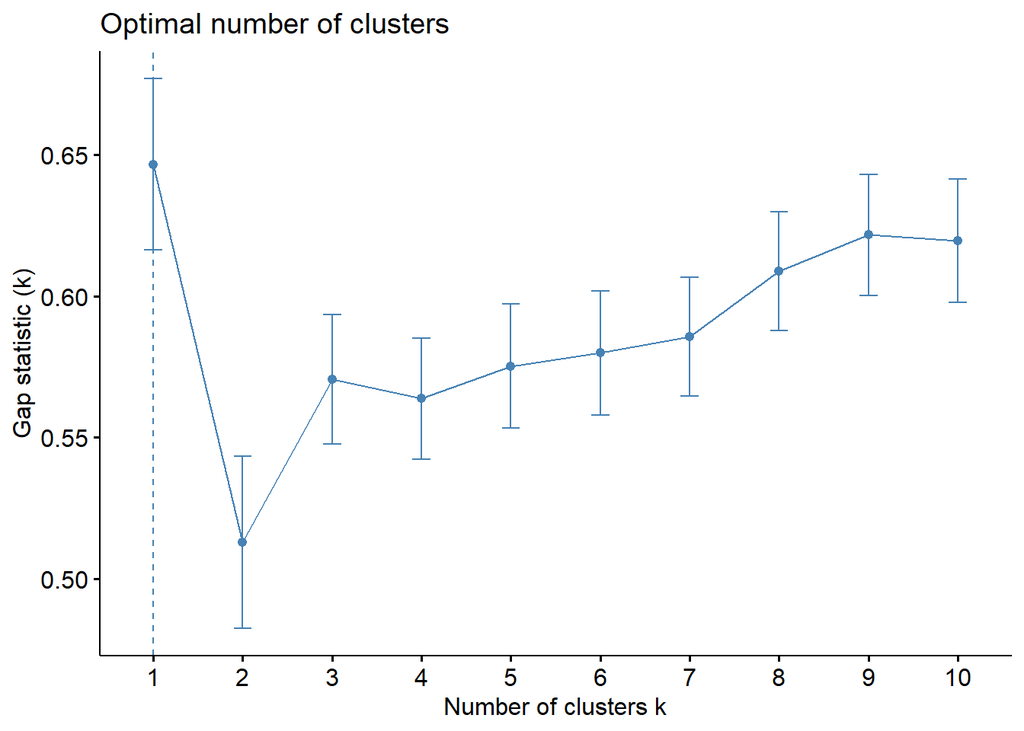

```r
set.seed(123)
fviz_nbclust(paraCluster, hcut,diss=g.dist,method = "gap_stat",k.max = 10,verbose = F,hc_func = "agnes")
```

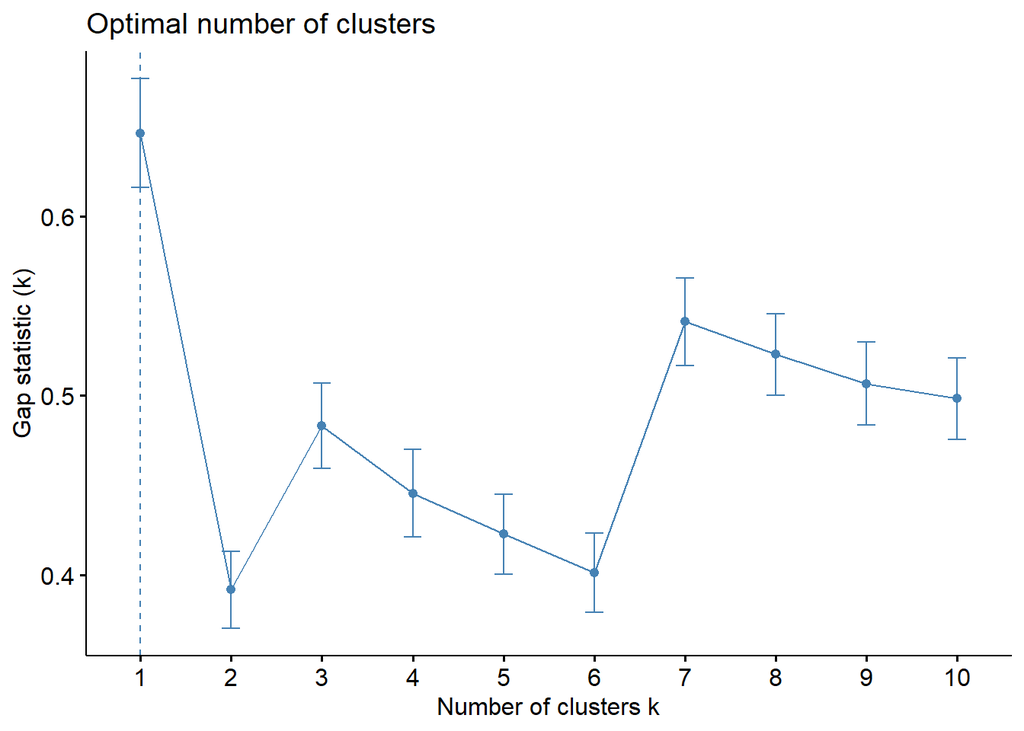

```r
set.seed(123)
fviz_nbclust(paraCluster, hcut,diss=g.dist,method = "gap_stat",k.max = 10,verbose = F,hc_func = "diana")
```

```
##   cluster size ave.sil.width
## 1       1   31          0.26
## 2       2   38          0.04
## 3       3   34          0.39
```

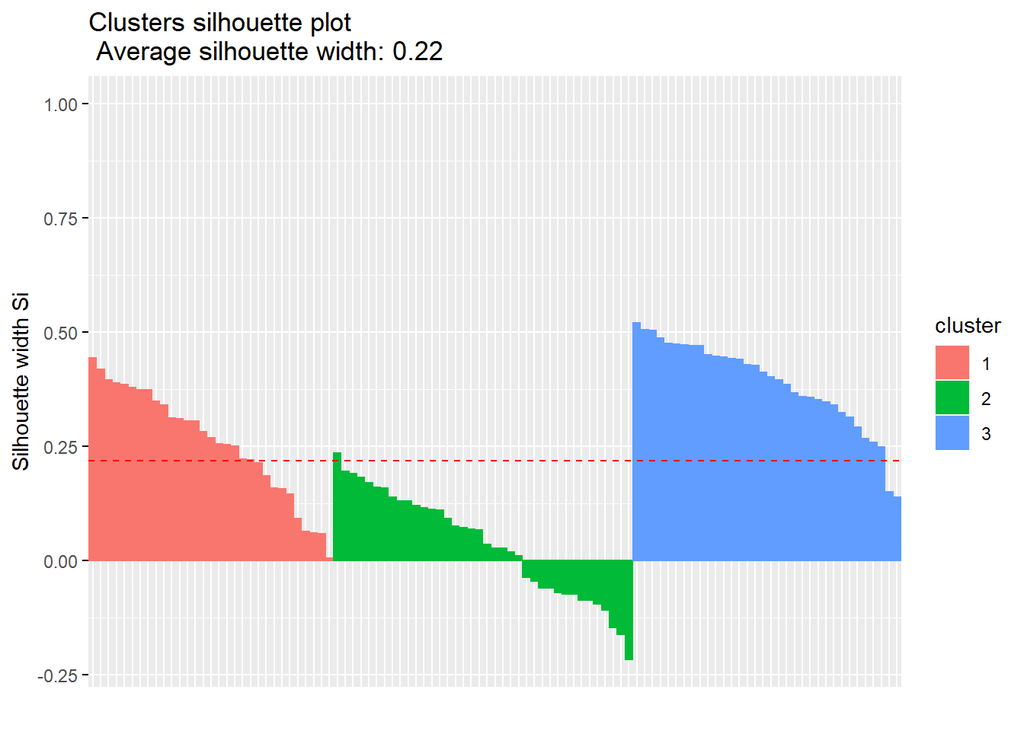

```r
set.seed(123)
SUGERIDOS=3
res.pam=pam(g.dist,k = SUGERIDOS,cluster.only = F)
res.agnes <- hcut(g.dist, k = SUGERIDOS,hc_func='agnes')
res.diana <- hcut(g.dist, k = SUGERIDOS,hc_func='diana')

fviz_silhouette(res.pam)
```

```
##   cluster size ave.sil.width
## 1       1   57          0.23
## 2       2   38          0.37
## 3       3    8          0.33
```

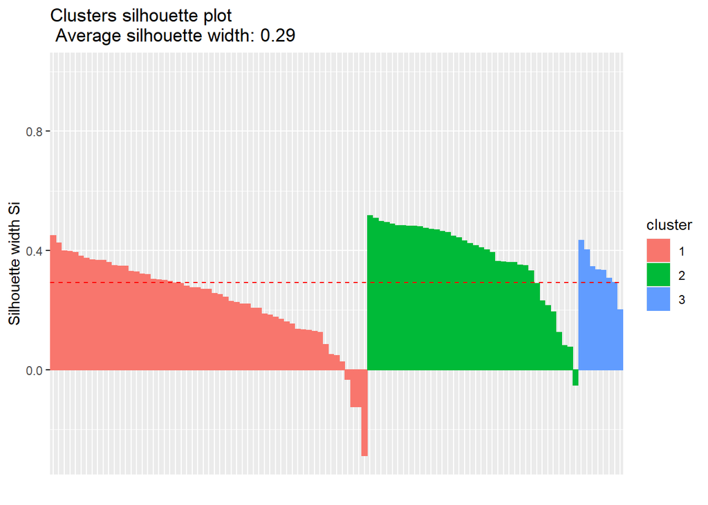

```r
fviz_silhouette(res.agnes)
```

```
##   cluster size ave.sil.width
## 1       1   89          0.32
## 2       2   10          0.31
## 3       3    4          0.10
```

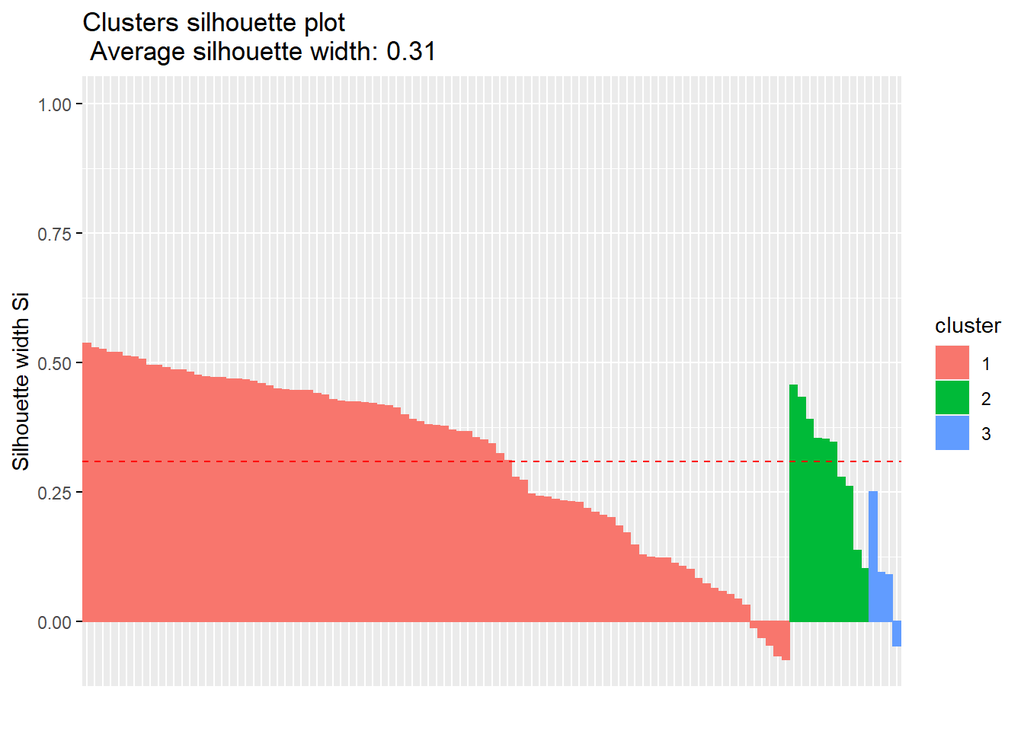

```r
fviz_silhouette(res.diana)
```

8. Bibliografia:

Educacion:

1. López Segrera, Francisco. Notas para un estudio comparado de la educación superior a nivel mundial. En publicacion: Escenarios mundiales de la educación superior. Análisis global y estudios de casos. López Segrera, Francisco. CLACSO, Consejo Latinoamericno de Ciencias Sociales. Noviembre 2007 ISBN 978-987-1183-61-6
2. Pandemia y educación superior. Rev. educ. sup [online]. 2020, vol.49, n.194, pp.1-8. Epub 27-Nov-2020. ISSN 0185-2760. https://doi.org/10.36857/resu.2020.194.1120.

3)Sánchez, M. C., & Araya, R. G. (2012). Desafíos de la educación en la sociedad actual. Diálogos educativos, (24), 55-69.

Gasto publico: 4)Mundial, B., & de Desarrollo, B. I. (2007). Informe sobre el gasto público. Tegucigalpa: Banco Mundial, Departamento de América Central.

5)Mundial, B. (1990). Informe sobre el desarrollo mundial 1990: la pobreza. Resumen.

6)Jiménez, C., & Flores-Chamba, J. (2021). Desigualdad y gasto público a nivel mundial: Un estudio con datos y metodologías de panel. Revista Económica, 9(2), 43-54.

Esperanza de vida:

7)Montes de Oca, V. (2003). El envejecimiento en el debate mundial: reflexión académica y política. Papeles de población, 9(35), 77-100.

8)Mundial, B. (1992). La medición de la pobreza. Comercio exterior, 42(4), 323-325.

9)Zibechi, R. (2020). A las puertas de un nuevo orden mundial. Sopa de Wuhan. Pensamiento contemporáneo en tiempos de pandemias, 113-118.